# Descriptives I: Country, Region and Frames

# Introduction

This is an overview of the key descriptives, a first step before any model building can be done.

## Countries and Regions

Among the most important distributions for the analysis is the Country * Level cell count. The problem here is the low N for a couple of countries -in particular France, Italy and Germany. Perhaps some more stories could simply be added manually (obviously after coding). A split of at least 70:30 would be the bare minimum.

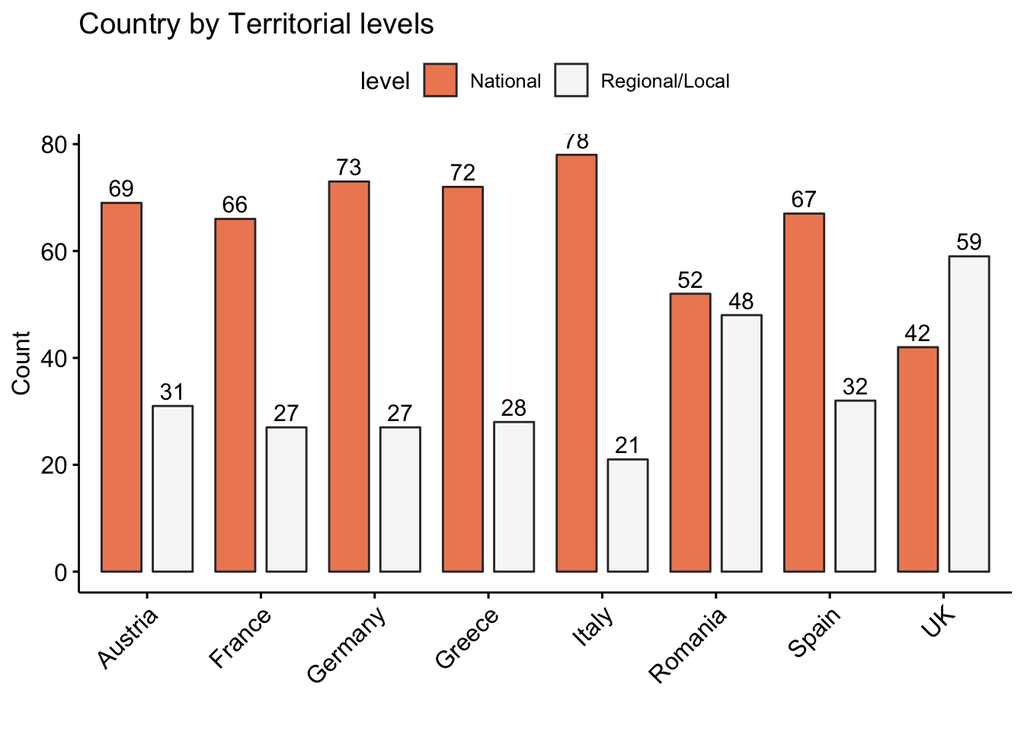

## Dominant Frames

Here we can see the issue of very low cell count for Dominant Frame in many country * territorial level cells. In particular the Regional level has very low (or simply missing counts) for three of the frames -the only one that has a reasonable distribution is Socio-Economic.

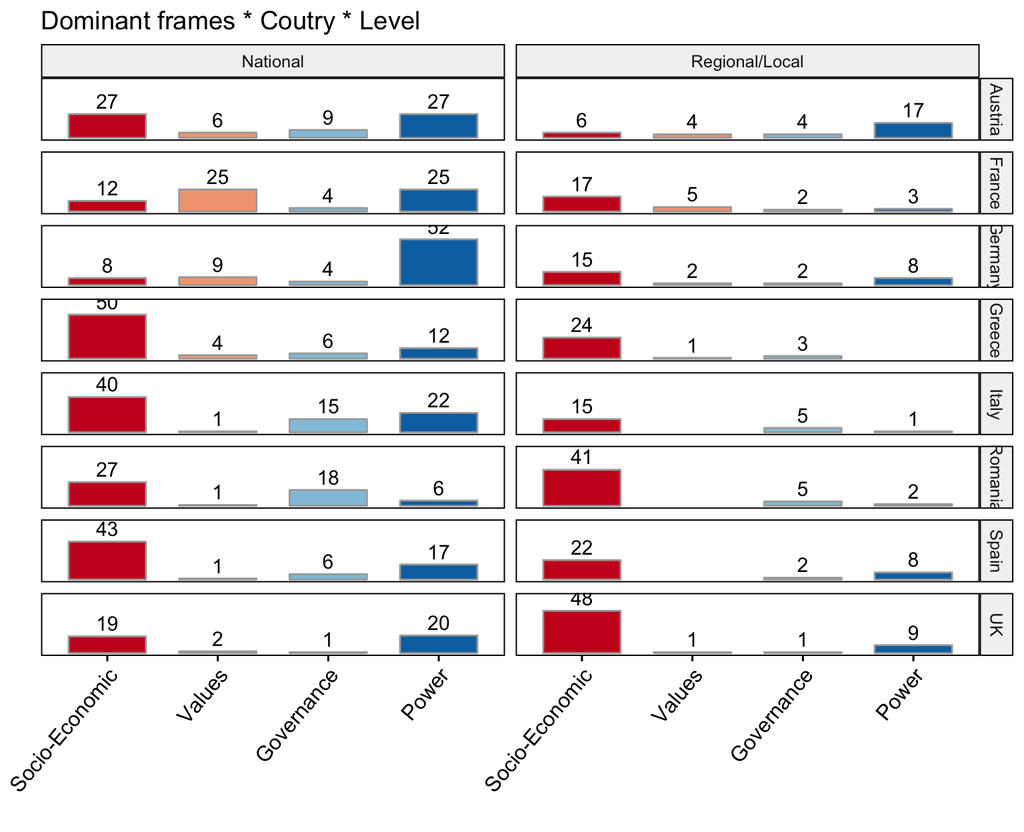

## Explore a higher level dimension

We can recode, and have a higher level dimension of Economic (socio-economic and values) vs Politics (governance and power). Obviously we can change the two labels.

This certainly improves things, the national level looks a bit better, and so does the regional -though there are some very low counts for say Greece.

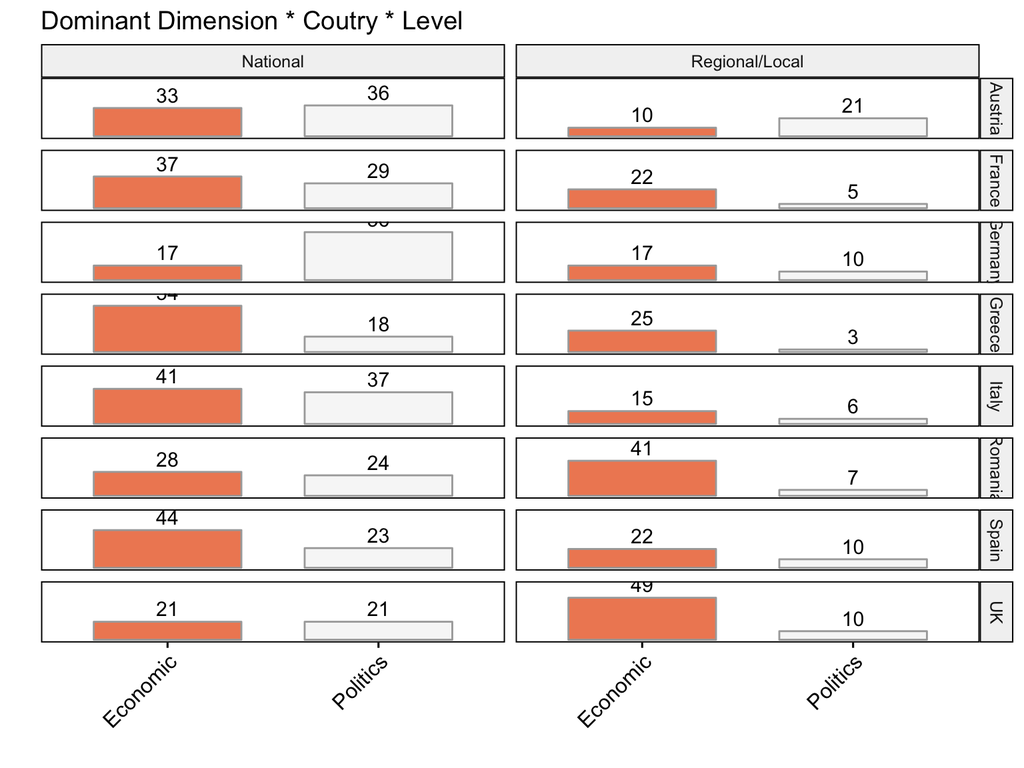

# Summary

There’s an issue with the cell count for Regional level, which is accentuated by Dominant frames. A recode to a higher level dimension, around Economics vs Politics, helps.